# Einführung in Webscraping und APIs mit Python

**Ziel:** Verstehen, wie Jupyter-Notebooks funktionieren, was Requests und Webscraping sind, und wie man reale APIs abfragt: Wechselkurse, Wetter, und Texterkennung (OCR).

> Zellen mit **Shift+Enter** ausführen. Code kann direkt bearbeitet werden. Ergebnisse erscheinen unter der jeweiligen Zelle.

## 1) Wie Jupyter-Notebooks funktionieren

Ein **Jupyter-Notebook** ist eine interaktive Arbeitsumgebung, in der wir Text, Code und Ergebnisse direkt miteinander kombinieren können. Es wird häufig in Datenanalyse, Lehre und Forschung verwendet, weil es Dokumentation und Ausführung in einer Oberfläche vereint. **Colab**, wo wir gerade sind, ist eine Gratis-Plattform von Google, über die man Jupyter-Notebooks online schreiben und ausführen kann, ohne sich um irgendetwas kümmern zu müssen.

- **Textzellen** (wie diese) dienen der Erklärung, Beschreibung oder Dokumentation. Sie werden in Markdown geschrieben und können Überschriften, Listen, Tabellen oder Formeln enthalten.
- **Codezellen** enthalten Python-Code, der durch Drücken von **Shift + Enter** ausgeführt wird. Das Ergebnis erscheint direkt darunter.
- **Zellen werden von oben nach unten** ausgeführt. Der Ablauf kann aber manuell gesteuert werden, d. h. man kann auch einzelne Zellen zwischendurch starten.
- **Variablen bleiben erhalten**, solange der sogenannte *Kernel* (die laufende Python-Sitzung) aktiv ist.
- **Ein Neustart des Kernels** löscht alle gespeicherten Variablen und den aktuellen Zustand – der Code muss dann erneut ausgeführt werden, um alles wiederherzustellen.

So entsteht ein nachvollziehbarer „Rechenbericht“, der Daten, Analysen und Erläuterungen transparent miteinander verbindet.

```python
# Ein minimaler Python-Code
x = 2
y = 3
x * y
```

```
6
```

### "Libraries"

In diesem Schritt nutzen wir `Pandas`. Pandas ist eine von vielen tausenden sogenannten **Libraries** in Python. Libraries sind Codepakete, die bestimmte Funktionen oder Werkzeuge enthalten, damit man sie nicht jedes Mal selbst schreiben muss. Einige davon sind sehr wichtig für die Arbeit mit Python und werden in quasi jedem Projekt genutzt.

**Beispiele häufig genutzter Libraries:**

| Library | Zweck |
| --- | --- |
| `pandas` | Arbeit mit Tabellen und strukturierten Daten |
| `numpy` | Mathematische Berechnungen und Arrays |
| `matplotlib` / `seaborn` | Datenvisualisierung |
| `openai` | Verbindung zu Sprachmodellen von OpenAI |

Um eine Library zu verwenden, muss sie zuerst **importiert** werden. Das Schlüsselwort `import` lädt den Code aus der Library in unser Programm, sodass ihre Funktionen verfügbar werden. Davor muss sie (eigentlich) in unserer Umgebung installiert werden, aber Colab hat viele häufig genutzte Libraries schon vorinstalliert.

**Beispiel:**

```
import pandas as pd
```

Dieser Befehl lädt die Library *pandas* und gibt ihr den Kurznamen `pd`. Dadurch können wir später Befehle wie `pd.DataFrame(...)` schreiben, anstatt jedes Mal `pandas.DataFrame(...)`.

Hier laden wir diese Library, und nutzen sie, um eine beispielhafte Tabelle zu kreieren.

```python
# Working with a tiny table using pandas
import pandas as pd
df = pd.DataFrame({
    "city": ["Berlin", "Bonn", "Hamburg"],
    "population_m": [3.85, 0.33, 1.85]
})
df
```

|  | city | population_m |
| --- | --- | --- |
| 0 | Berlin | 3.85 |
| 1 | Bonn | 0.33 |
| 2 | Hamburg | 1.85 |

## 2) Requests: Das Internet aus dem Notebook ansprechen

In diesem Abschnitt lernen wir, wie unser Notebook mit dem **Internet kommuniziert**.  
Dazu müssen wir verstehen, was ein sogenannter **HTTP-Request** ist.

### Was ist ein HTTP-Request?

Wenn wir eine Webseite im Browser öffnen, passiert technisch Folgendes: Unser Computer schickt eine standardisierte **Anfrage (Request)** an den Server der Webseite.  
Der Server antwortet mit einer **Antwort (Response)** – meist in Form von HTML-Code, Bildern oder anderen Dateien.

Dieses Protokoll heißt **HTTP** (*Hypertext Transfer Protocol*).  
Es ist ein weltweiter Standard, der **nichts mit Python zu tun hat** – jedes Programm, jeder Browser und auch viele Maschinenkommunikationen nutzen HTTP, um übers Internet Daten auszutauschen.

Ein Request besteht typischerweise aus:

- einer **URL** (z. B. `https://example.com`),
- einer **Methode** (z. B. GET, POST, PUT – beschreibt, was man tun will),
- und optional **Parametern oder Daten**, die mitgeschickt werden.

### Requests in Python

In Python können wir solche HTTP-Anfragen mit der Library `requests` verschicken.  
Diese Bibliothek kümmert sich darum, dass alles im richtigen Format übertragen wird und wir die Antwort einfach weiterverarbeiten können.

💡 Mit `requests.get("https://example.com")` wird also exakt dieselbe Anfrage geschickt, wie unser Browser sie stellen würde – nur ohne sichtbare Benutzeroberfläche.

`requests` ist keine Kernkomponente von Python selbst, gehört aber zu den **Standardbibliotheken**, die in quasi jeder Version von Python vorinstalliert sind.  
Importieren muss man sie trotzdem:

```
import requests
```

### HTML und BeautifulSoup

Die Antwort auf einen HTTP-Request ist bei Webseiten meist **HTML-Code** – also Text, der beschreibt, wie die Seite aufgebaut ist. Damit wir daraus gezielt Informationen (z. B. den Titel) herausfiltern können, verwenden wir die Library **BeautifulSoup**.

`beautifulsoup` analysiert HTML-Strukturen und ermöglicht es, gezielt Elemente zu suchen, etwa `<title>`, `<p>`, `<div>` usw. Für unseren Kurs reicht es zu wissen, dass sie „den HTML-Code in eine strukturierte Form bringt, mit der man arbeiten kann“.

Dokumentation: https://pypi.org/project/beautifulsoup4/

### Übung

In der nächsten Zelle rufen wir eine Webseite auf und versuchen, **automatisch ihren Titel** auszulesen.

**Hinweis:**

- Fast jede Webseite hat ein `<h1>`-Element, aber nicht alle.
- Komplexere Strukturen zu extrahieren ist deutlich schwieriger.
- Viele Seiten verhindern absichtlich automatisches Auslesen (*Webscraping*), z. B. durch technische Schutzmaßnahmen oder dynamische Inhalte.

💡 Webseiten sind primär für den **menschlichen Blick** gebaut – nicht für Programme. Wenn man versucht, sie maschinell auszulesen, nutzt man sie **zweckentfremdet**, und die Ergebnisse können unzuverlässig sein.

```python
import requests
from bs4 import BeautifulSoup

url = "https://www.faz.net/aktuell/gesellschaft/ungluecke/1000-menschen-am-mount-everest-von-schneesturm-eingeschlossen-accg-110717479.html"

try:
    response = requests.get(url, timeout=10)
    response.raise_for_status()  # Raise an exception for bad status codes

    print("So sieht der Start des HTMLs für diese Seite aus:")
    print("----------")
    print(response.text[:300])

    soup = BeautifulSoup(response.content, 'html.parser')
    h1_tag = soup.find('h1')


    if h1_tag:
        print("----------")
        print(f"Der Titel von {url} ist: {h1_tag.text}")
    else:
        print(f"Kein HTML Tag gefunden")

except requests.exceptions.RequestException as e:
    print(f"Fehler beim Aufruf der URL: {e}")
```

```
So sieht der Start des HTMLs für diese Seite aus:
----------
<!DOCTYPE html><html  class="light-mode" lang="de" data-capo=""><head><meta charset="utf-8">
<meta name="viewport" content="width=device-width, initial-scale=1">
<title>1000 Menschen am Mount Everest von Schneesturm eingeschlossen | FAZ</title>
<link rel="preconnect" href="//ttmetrics.faz.net">
<lin
----------
Der Titel von https://www.faz.net/aktuell/gesellschaft/ungluecke/1000-menschen-am-mount-everest-von-schneesturm-eingeschlossen-accg-110717479.html ist: 1000 Menschen am Mount Everest von Schneesturm eingeschlossen
```

## 3) Eine API abrufen: Wechselkurse

Jetzt nutzen wir wieder `requests`, aber diesmal nicht, um eine Webseite aufzurufen, sondern um eine **API** anzusprechen.

Eine **API** (*Application Programming Interface*) ist eine Schnittstelle, über die Computerprogramme standardisiert miteinander kommunizieren.  
Im Gegensatz zu normalen Webseiten, die für Menschen gestaltet sind, sind APIs **von Anfang an für Maschinen gemacht**.  
Sie liefern Daten immer in klar definierten Strukturen (meist **JSON** oder **XML**), damit Programme sie automatisch weiterverarbeiten können.

### Beispiel: Wechselkurse

Wir verwenden hier **exchangerate.host**, eine kostenlose öffentliche API, die aktuelle Währungswechselkurse bereitstellt.

Das Prinzip ist dabei dasselbe wie beim Webseitenaufruf:  
Wir schicken einen standardisierten **HTTP-Request** (z. B. `GET`) an eine bestimmte URL, und der Server antwortet mit Daten – diesmal jedoch nicht als HTML-Seite, sondern als Datensatz.

### API-Authentifizierung und API-Keys

Viele APIs bieten wertvolle oder sensible Informationen an (z. B. personenbezogene Daten oder kostenpflichtige Dienste).  
Zudem verursacht jeder Abruf Serverkosten. Deshalb sind die meisten APIs **nicht frei zugänglich**.

Üblich ist folgendes System:

1. Man registriert sich auf der Webseite des Anbieters.
2. Man erhält einen **API-Schlüssel (API key)** – eine eindeutige Zeichenfolge aus Buchstaben und Zahlen.
3. Dieser Schlüssel wird bei jeder Anfrage mitgeschickt, um sich zu authentifizieren und die Nutzung zuzuordnen.

Beispiel:

```
params = {"apikey": "MEIN_GEHEIMER_SCHLUESSEL"}
`
```

So weiß der Anbieter, von wem die Anfrage stammt. Gleichzeitig kann er Zugriffe limitieren oder abrechnen. Ein API-Key sollte **nie öffentlich im Code stehen**, sondern z. B. in einer Umgebungsvariable gespeichert werden. Was wir hier in diesem Notebook machen ist **sehr schlecht** 😡 (aber nicht so wild, weil die API Keys alle keine Daten oder Zahlungsmethoden hinterlegt haben).

### Warum APIs wichtig sind

APIs sind die **Schnittstellen der digitalen Welt** – sie verbinden Systeme, Anwendungen und Datenquellen miteinander.  
Fast jedes moderne Softwareprodukt – egal ob im öffentlichen oder privaten Sektor – bietet heute eine API an, um Daten auszutauschen oder Funktionen bereitzustellen.

Einige der wichtigsten **Arten von APIs** sind:

- **Daten-APIs:** stellen strukturierte Informationen bereit, z. B. aus Datenbanken, Statistiksystemen oder öffentlichen Registern (Beispiel: EU-Open-Data-Portal, Statistisches Bundesamt).
- **System-APIs:** ermöglichen die Integration von Verwaltungs-, ERP- oder CRM-Systemen wie **SAP**, **Salesforce** oder **Dokumentenmanagementsystemen**.
- **Sprachmodell- und KI-APIs:** bieten Zugriff auf generative KI, Übersetzung, Textanalyse oder Bilderkennung (Beispiele: **OpenAI**, **Google Cloud AI**, **Hugging Face**).
- **Echtzeit- und Sensordaten-APIs:** liefern aktuelle Messwerte, z. B. Wetterdaten, Verkehr, Energieverbrauch oder Luftqualität (Beispiel: **Open-Meteo**, **Transport APIs**).
- **Zahlungs- und Authentifizierungs-APIs:** sorgen für sichere Identifikation und Transaktionen (z. B. **OAuth**, **PayPal**, **BundID**).

Gemeinsam ist all diesen Schnittstellen, dass sie **strukturiert**, **standardisiert** und **maschinenlesbar** sind – im Gegensatz zu Webseiten, die für Menschen gestaltet wurden.  
Dadurch können Systeme:

- Daten automatisiert abrufen oder aktualisieren,
- Informationen zwischen Anwendungen synchronisieren,
- Prozesse über Organisationsgrenzen hinweg verbinden.

APIs sind damit die **Sprachkanäle moderner Informationssysteme** – sie machen es möglich, dass einzelne digitale Dienste zu einem vernetzten Ökosystem werden.

### Was passiert technisch?

In unserem Code:

1. Wir schicken einen Request an die URL `BASE`.
2. Wir legen einen **Timeout** (z. B. 20 Sekunden) fest, damit das Programm nicht ewig wartet, falls keine Antwort kommt.
3. Wir erhalten eine strukturierte Antwort, die wir direkt weiterverarbeiten können.

Der entscheidende Punkt:

💡 API-Antworten folgen **immer einer klar definierten Struktur**. Dadurch wissen wir genau, welche Felder vorhanden sind und können sie zuverlässig auslesen – anders als beim Webscraping, wo das Seitenlayout sich jederzeit ändern kann.

**⚠ Hinweis: Bitte diesen Codeblock nur einmal ausführen! Dieser API-Key ist auf 100 Anfragen im Monat begrenzt, die für uns alle reichen müssen.**

```python
import requests

BASE = "https://api.exchangerate.host/live"
api_key = "91850d33367fc44f6f7ef1d73f7ae73b"
params = {"access_key": api_key}

resp = requests.get(BASE, params=params, timeout=20)
resp.raise_for_status()
data = resp.json()
```

Die Daten, die wir zurückbekommen, sind eine lange Liste an Wechselkursen:

```python
data
```

```
{'success': True,
 'terms': 'https://currencylayer.com/terms',
 'privacy': 'https://currencylayer.com/privacy',
 'timestamp': 1759680788,
 'source': 'USD',
 'quotes': {'USDAED': 3.672504,
  'USDAFN': 67.092543,
  'USDALL': 82.432605,
  'USDAMD': 383.203441,
  'USDANG': 1.790403,
  'USDAOA': 917.000367,
  'USDARS': 1423.999489,
  'USDAUD': 1.514704,
  'USDAWG': 1.40625,
  'USDAZN': 1.70397,
  'USDBAM': 1.665858,
  'USDBBD': 2.013373,
  'USDBDT': 121.655807,
  'USDBGN': 1.66609,
  'USDBHD': 0.3769,
  'USDBIF': 2944.593501,
  'USDBMD': 1,
  'USDBND': 1.288787,
  'USDBOB': 6.907713,
  'USDBRL': 5.338504,
  'USDBSD': 0.999617,
  'USDBTC': 8.15857e-06,
  'USDBTN': 88.813083,
  'USDBWP': 13.28819,
  'USDBYN': 3.389379,
  'USDBYR': 19600,
  'USDBZD': 2.010477,
  'USDCAD': 1.39655,
  'USDCDF': 2535.000362,
  'USDCHF': 0.790154,
  'USDCLF': 0.024452,
  'USDCLP': 959.260679,
  'USDCNY': 7.119504,
  'USDCNH': 7.13601,
  'USDCOP': 3884.161663,
```

[output cut: 121 more lines]

```
  'USDVUV': 120.888181,
  'USDWST': 2.783193,
  'USDXAF': 558.713002,
  'USDXAG': 0.020837,
  'USDXAU': 0.000257,
  'USDXCD': 2.70255,
  'USDXCG': 1.801627,
  'USDXDR': 0.69486,
  'USDXOF': 558.713002,
  'USDXPF': 101.580001,
  'USDYER': 239.050363,
  'USDZAR': 17.22816,
  'USDZMK': 9001.203584,
  'USDZMW': 23.816703,
  'USDZWL': 321.999592}}
```

Wie viel sind jetzt gerade 250 USD in Euro?

Weil die Datenstruktur vorgegeben ist, können wir Werte daraus automatisiert nutzen und damit arbeiten, ohne Angst, dass am Format was nicht stimmt.

👉 Ändere die Summe in USD auf einen anderen Wert oder den Wechselkurs auf einen anderen aus der obigen Liste, indem du die ersten zwei Zeilen änderst.

```python
summe_in_usd = 250
wechselkurs = 'USDEUR'

andere_waehrung = wechselkurs[3:]
kurs = data['quotes'][wechselkurs]
print(f"1 USD = {kurs} {andere_waehrung}")
print(f"{summe_in_usd} USD = {summe_in_usd * kurs} {andere_waehrung}")
```

```
1 USD = 0.851704 EUR
250 USD = 212.92600000000002 EUR
```

## 4) Noch eine API abrufen: Open-Meteo

Kein API-Schlüssel nötig. Wir holen stündliche Temperaturdaten für Berlin und erstellen eine einfache Grafik. Hierbei lernen wir noch zwei neue Dinge über APIs:

- Eine API kann viele verschiedene **„Routen“** anbieten – also Endpunkte mit unterschiedlichen URLs, die jeweils andere Daten oder Funktionen bereitstellen. Zum Beispiel nutzen wir hier die Route `/forecast`, um eine Wettervorhersage zu bekommen. Andere Routen können etwa historische Wetterdaten, Klimadaten oder Windinformationen liefern.
- Über das Argument `params` übergeben wir der API **Parameter**, also zusätzliche Informationen, die steuern, welche Daten wir möchten. Diese Parameter sagen der API in diesem Fall zum Beispiel:
  - **Ort:** z. B. durch geografische Koordinaten (`latitude`, `longitude`)
  - **Zeitraum oder Frequenz:** z. B. stündlich (`hourly`) oder täglich (`daily`)
  - **Messgrößen:** z. B. Temperatur, Wind, Luftfeuchtigkeit

Die API verarbeitet diese Angaben und liefert die passenden Daten als Antwort zurück – meist im **JSON-Format**, also einer klar strukturierten Textform, die Python leicht weiterverarbeiten kann.

Welche Routen eine API anbietet und welche Parameter jede Route akzeptiert, steht immer in der **Dokumentation**. Diese findet man in der Regel auf der Website der API-Anbieter – in diesem Fall hier: https://open-meteo.com/en/docs

👉 Ändere die lat und lon-Werte, um die Vorhersage für eine andere Stadt abzurufen. Schaffst du es, mithilfe der API-Dokumentation was ganz anderes abzurufen, z.B. die Regenwahrscheinlichkeit?

```python
# Berlin Koordinaten
lat, lon = 52.52, 13.405
url = "https://api.open-meteo.com/v1/forecast"
params = {
    "latitude": lat,
    "longitude": lon,
    "hourly": "temperature_2m",
    "timezone": "Europe/Berlin"
}
r = requests.get(url, params=params, timeout=20)
r.raise_for_status()
wx = r.json()
# Build DataFrame
hourly = pd.DataFrame({
    "time": pd.to_datetime(wx["hourly"]["time"]),
    "temp_c": wx["hourly"]["temperature_2m"]
})
hourly.head()
```

|  | time | temp_c |
| --- | --- | --- |
| 0 | 2025-10-05 00:00:00 | 10.1 |
| 1 | 2025-10-05 01:00:00 | 9.7 |
| 2 | 2025-10-05 02:00:00 | 9.7 |
| 3 | 2025-10-05 03:00:00 | 9.6 |
| 4 | 2025-10-05 04:00:00 | 9.8 |

Hier plotten wir dann einfach die Werte, die wir bekommen haben. Wir nutzen die häufig genutzte Library `matplotlib`, die ziemlich unhandlich ist, darum muss dieser Block nur ausgeführt werden.

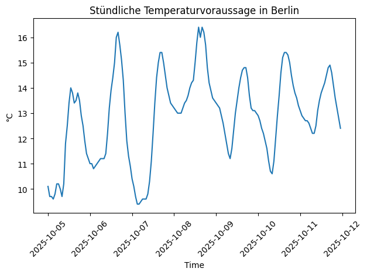

```python
import matplotlib.pyplot as plt

# Plot hourly temperature
plt.figure()
plt.plot(hourly["time"], hourly["temp_c"])
plt.title("Stündliche Temperaturvoraussage in Berlin")
plt.xlabel("Time")
plt.ylabel("°C")
plt.xticks(rotation=45)
plt.tight_layout()
plt.show()
```

## 5) OCR einer lokalen Datei per API

Jetzt beschäftigen wir uns mit **Texterkennung (OCR)** – also der automatischen Umwandlung von Text, der in einem Bild oder Scan enthalten ist, in echten, digitalen Text.

**OCR** steht für *Optical Character Recognition* und ist eine grundlegende Technologie, um analoge oder gescannte Dokumente maschinenlesbar zu machen.

Wenn man etwa ein eingescanntes Formular oder einen alten Boardingpass hat, liegt der Text darin nur als Pixelmuster vor – für ein KI-System oder ein Skript ist das zunächst unbrauchbar.

OCR analysiert das Bild, erkennt Buchstaben und Zahlen und erzeugt daraus eine Textversion, die man weiterverarbeiten kann.

### Ablauf

👉 Wir laden eine Datei von unserem Computer in die Colab-Umgebung hoch. → Das kann z. B. ein PDF oder ein eingescanntes Formular sein.

1. Wir senden die Datei über `requests.post()` an die OCR.space-API.  
   Diese erkennt den enthaltenen Text automatisch.
2. Die API gibt das Ergebnis als **JSON** zurück.  
   Wir lesen das Feld `ParsedText` aus und zeigen den erkannten Text an.

### Warum OCR wichtig ist

OCR ist ein **entscheidender erster Schritt**, wenn man vorhandene Dokumente oder Datenbestände für moderne KI-Anwendungen nutzbar machen möchte.  
In Verwaltungen, Unternehmen oder Archiven liegen viele Informationen in **nicht-digitaler oder schlecht strukturierter Form** vor – etwa als Scan, Fax oder Formular.  
LLMs und andere Sprachmodelle können diese Inhalte nur verarbeiten, wenn sie als Text vorliegen.

Allerdings endet der Prozess hier noch nicht:  
Der Text, den OCR zurückliefert, ist in der Regel **nicht strukturiert** – es handelt sich um reinen Fließtext ohne erkennbare Felder, Tabellen oder Metadaten.  
Bevor man ihn mit einem Sprachmodell sinnvoll verwenden kann, müssen daher oft noch weitere Schritte folgen:

- **Bereinigung:** Entfernen von Artefakten, Zeilenumbrüchen oder fehlerhaften Zeichen.
- **Strukturierung:** Zuordnung zu Datenfeldern (z. B. Name, Datum, Preis, Referenznummer).
- **Anreicherung:** Kombination mit anderen Datenquellen oder Metadaten.

Erst danach lassen sich die Inhalte zuverlässig durchsuchen, auswerten oder in KI-Systeme einspeisen.  
OCR ist also das **Tor zur Digitalisierung** – aber erst der Anfang der eigentlichen Datenverarbeitung.

**Hinweise:**

- Sprache passend einstellen (`language="deu"`, `"eng"` oder `"eng+deu"`).
- Niedrige Scanauflösung → `scale=True` setzen.

👉 Probiere es mit "pass_1.pdf" und den anderen beiden Dateien aus. Probiere es auch gerne mit irgendwelchen anderen PDFs aus, welche datenschutztechnisch unkritisch sind.

```python
API_KEY = "K88263510188957"
url = "https://api.ocr.space/parse/image"
fname = "pass_1.pdf"

with open(fname, "rb") as f:
    resp = requests.post(
        url,
        files={"file": (fname, f)},
        data={
            "language": "eng",
            "isOverlayRequired": False,
            "OCREngine": 2,
            "scale": True,
            "detectOrientation": True,
        },
        headers={"apikey": API_KEY},
        timeout=120,
    )

resp.raise_for_status()
data = resp.json()
text = (data.get("ParsedResults",[{}])[0].get("ParsedText","") or "").strip()
print(text[:1000])
```

[output not shown]

## 7) Hauptpunkte

1. `Webscraping` ist eine Methode, um Daten aus öffentlichen Webseiten abzugreifen. So kann theoretisch das gesamte Internet als Datenquelle genutzt werden. In der Praxis ist Webscraping oft unverlässlich, die Daten sind am Ende unstrukturiert, und zunehmend blockieren Webanbieter es ganz.
2. `APIs` sind Schnittstellen, über die Programme strukturiert miteinander kommunizieren können. Mit `Parametern` und Auswahl von `Routes` kann spezifiziert werden, was genau von einem API gewollt ist.
3. Was bei einem API "hinter den Kulissen" passiert ist uns "egal": wir schicken nur eine Anfrage, und bekommen eine Antwort.